# Homework1

## QUESTION 1

### a)Code

```r
require(data.table)
require(anytime)
```

```r
matches=readRDS ('/Users/esinakgul/Documents/BOUN/4-1/IE 582/HOMEWORK/Homework 1/df9b1196-e3cf-4cc7-9159-f236fe738215_matches.rds')

odds=readRDS ('/Users/esinakgul/Documents/BOUN/4-1/IE 582/HOMEWORK/Homework 1/df9b1196-e3cf-4cc7-9159-f236fe738215_odd_details.rds')

matches[,match_time:=anytime(date)]
matches[,c("HomeGoals","AwayGoals"):=tstrsplit(score,':')]
matches[,Year:=year(match_time)]

matches$HomeGoals=as.numeric(matches$HomeGoals)
matches[,AwayGoals:=as.numeric(AwayGoals)]


matches[,TotalGoals:=HomeGoals+AwayGoals]

matches[,IsOver:=0]
matches[TotalGoals>2,IsOver:=1]

matches=matches[complete.cases(matches)]

odds_ov_un=odds[betType=='ou' & totalhandicap=='2.5']

odds_ov_un[,totalhandicap:=NULL]

odds_ov_un=odds_ov_un[order(matchId, oddtype,bookmaker,date)]

odds_ov_un_initial=odds_ov_un[,list(start_odd=odd[1]),
                              by=list(matchId,oddtype,bookmaker)]

odds_ov_un_final=odds_ov_un[,list(final_odd=odd[.N]),
                            by=list(matchId,oddtype,bookmaker)]

#pinnacle initial

pinnacle_over_under_initial=odds_ov_un_initial[bookmaker=='Pinnacle']

pinnacle_wide_initial=dcast(pinnacle_over_under_initial,
                    matchId~oddtype,
                    value.var='start_odd')

merged_matches_Pinnacle_initial=merge(matches, pinnacle_wide_initial, by='matchId')

merged_matches_Pinnacle_initial[,probOver:=1/over]
merged_matches_Pinnacle_initial[,probUnder:=1/under]

merged_matches_Pinnacle_initial[,totalProb:=probOver+probUnder]

merged_matches_Pinnacle_initial[,probOver:=probOver/totalProb]
merged_matches_Pinnacle_initial[,probUnder:=probUnder/totalProb]

merged_matches_Pinnacle_initial=merged_matches_Pinnacle_initial[complete.cases(merged_matches_Pinnacle_initial)]
merged_matches_Pinnacle_initial[,totalProb:=NULL]

cutpoints=seq(0,1,0.1)
merged_matches_Pinnacle_initial[,odd_cut_over:=cut(probOver,cutpoints)]

summary_table_Pinnacle_initial=merged_matches_Pinnacle_initial[,list(empirical_over=mean(IsOver),
                                   probabilistic_over=mean(probOver),.N),
                             by=list(Year,odd_cut_over)]

summary_table_Pinnacle_initial=summary_table_Pinnacle_initial[order(Year)]





#Pinnacle final

pinnacle_over_under_final=odds_ov_un_final[bookmaker=='Pinnacle']

pinnacle_wide_final=dcast(pinnacle_over_under_final,
                            matchId~oddtype,
                            value.var='final_odd')

merged_matches_Pinnacle_final=merge(matches, pinnacle_wide_final, by='matchId')

merged_matches_Pinnacle_final[,probOver:=1/over]
merged_matches_Pinnacle_final[,probUnder:=1/under]

merged_matches_Pinnacle_final[,totalProb:=probOver+probUnder]

merged_matches_Pinnacle_final[,probOver:=probOver/totalProb]
merged_matches_Pinnacle_final[,probUnder:=probUnder/totalProb]

merged_matches_Pinnacle_final=merged_matches_Pinnacle_final[complete.cases(merged_matches_Pinnacle_final)]
merged_matches_Pinnacle_final[,totalProb:=NULL]

cutpoints=seq(0,1,0.1)
merged_matches_Pinnacle_final[,odd_cut_over:=cut(probOver,cutpoints)]

summary_table_Pinnacle_final=merged_matches_Pinnacle_final[,list(empirical_over=mean(IsOver),
                                                                     probabilistic_over=mean(probOver),.N),
                                                               by=list(Year,odd_cut_over)]

summary_table_Pinnacle_final=summary_table_Pinnacle_final[order(Year)]

par(mfrow=c(2,3))
plot(summary_table_Pinnacle_initial[,list(empirical_over,probabilistic_over)],ylab='Calculated Probability', xlab='Empirical Probability', pch=1,cex=2)


points(summary_table_Pinnacle_final[,list(empirical_over,probabilistic_over)],pch=2,cex=1,col='purple')
legend("topleft", c("Pinnacle Initial", "Pinnacle Final"),
       col=c("black","purple"), pch=1:2, cex=0.8)
legend(0.45,0.6, c("x=y"),
       col=c("red"), lty=1, cex=0.8)
title("Initial and Final Odds of Pinnacle",
      cex.main = 1,   font.main= 4, col.main= "blue")
abline(0,1,col='red')


#youwin initial

youwin_over_under_initial=odds_ov_un_initial[bookmaker=='youwin']

youwin_wide_initial=dcast(youwin_over_under_initial,
                            matchId~oddtype,
                            value.var='start_odd')

merged_matches_youwin_initial=merge(matches, youwin_wide_initial, by='matchId')

merged_matches_youwin_initial[,probOver:=1/over]
merged_matches_youwin_initial[,probUnder:=1/under]

merged_matches_youwin_initial[,totalProb:=probOver+probUnder]

merged_matches_youwin_initial[,probOver:=probOver/totalProb]
merged_matches_youwin_initial[,probUnder:=probUnder/totalProb]

merged_matches_youwin_initial=merged_matches_youwin_initial[complete.cases(merged_matches_youwin_initial)]
merged_matches_youwin_initial[,totalProb:=NULL]

cutpoints=seq(0,1,0.1)
merged_matches_youwin_initial[,odd_cut_over:=cut(probOver,cutpoints)]

summary_table_youwin_initial=merged_matches_youwin_initial[,list(empirical_over=mean(IsOver),
                                                                     probabilistic_over=mean(probOver),.N),
                                                               by=list(Year,odd_cut_over)]

summary_table_youwin_initial=summary_table_youwin_initial[order(Year)]


#youwin final

youwin_over_under_final=odds_ov_un_final[bookmaker=='youwin']

youwin_wide_final=dcast(youwin_over_under_final,
                          matchId~oddtype,
                          value.var='final_odd')

merged_matches_youwin_final=merge(matches, youwin_wide_final, by='matchId')

merged_matches_youwin_final[,probOver:=1/over]
merged_matches_youwin_final[,probUnder:=1/under]

merged_matches_youwin_final[,totalProb:=probOver+probUnder]

merged_matches_youwin_final[,probOver:=probOver/totalProb]
merged_matches_youwin_final[,probUnder:=probUnder/totalProb]

merged_matches_youwin_final=merged_matches_youwin_final[complete.cases(merged_matches_youwin_final)]
merged_matches_youwin_final[,totalProb:=NULL]

cutpoints=seq(0,1,0.1)
merged_matches_youwin_final[,odd_cut_over:=cut(probOver,cutpoints)]
```

```r
summary_table_youwin_final=merged_matches_youwin_final[,list(empirical_over=mean(IsOver),
                                                                 probabilistic_over=mean(probOver),.N),
                                                           by=list(Year,odd_cut_over)]

summary_table_Pinnacle_final=summary_table_Pinnacle_final[order(Year)]

plot(summary_table_youwin_initial[,list(empirical_over,probabilistic_over)],ylab='Calculated Probability', xlab='Empirical Probability',pch=1,cex=2)

points(summary_table_youwin_final[,list(empirical_over,probabilistic_over)],pch=2,cex=1,col='purple')

legend("topleft", c("Youwin Initial", "Youwin Final"),
       col=c("black","purple"), pch=1:2, cex=0.8)
legend(0.45,0.6, c("x=y"),
       col=c("red"), lty=1, cex=0.8)
title("Initial and Final Odds of Youwin",
      cex.main = 1,   font.main= 4, col.main= "blue")
abline(0,1,col='red')

#Tipico initial


Tipico_over_under_initial=odds_ov_un_initial[bookmaker=='Tipico']

Tipico_wide_initial=dcast(Tipico_over_under_initial,
                          matchId~oddtype,
                          value.var='start_odd')

merged_matches_Tipico_initial=merge(matches, Tipico_wide_initial, by='matchId')

merged_matches_Tipico_initial[,probOver:=1/over]
merged_matches_Tipico_initial[,probUnder:=1/under]

merged_matches_Tipico_initial[,totalProb:=probOver+probUnder]

merged_matches_Tipico_initial[,probOver:=probOver/totalProb]
merged_matches_Tipico_initial[,probUnder:=probUnder/totalProb]

merged_matches_Tipico_initial=merged_matches_Tipico_initial[complete.cases(merged_matches_Tipico_initial)]
merged_matches_Tipico_initial[,totalProb:=NULL]

cutpoints=seq(0,1,0.1)
merged_matches_Tipico_initial[,odd_cut_over:=cut(probOver,cutpoints)]

summary_table_Tipico_initial=merged_matches_Tipico_initial[,list(empirical_over=mean(IsOver),
                                                                 probabilistic_over=mean(probOver),.N),
                                                           by=list(Year,odd_cut_over)]

summary_table_Tipico_initial=summary_table_Tipico_initial[order(Year)]


#Tipico final

Tipico_over_under_final=odds_ov_un_final[bookmaker=='Tipico']

Tipico_wide_final=dcast(Tipico_over_under_final,
                        matchId~oddtype,
                        value.var='final_odd')

merged_matches_Tipico_final=merge(matches, Tipico_wide_final, by='matchId')

merged_matches_Tipico_final[,probOver:=1/over]
merged_matches_Tipico_final[,probUnder:=1/under]

merged_matches_Tipico_final[,totalProb:=probOver+probUnder]

merged_matches_Tipico_final[,probOver:=probOver/totalProb]
merged_matches_Tipico_final[,probUnder:=probUnder/totalProb]

merged_matches_Tipico_final=merged_matches_Tipico_final[complete.cases(merged_matches_Tipico_final)]
merged_matches_Tipico_final[,totalProb:=NULL]

cutpoints=seq(0,1,0.1)
merged_matches_Tipico_final[,odd_cut_over:=cut(probOver,cutpoints)]

summary_table_Tipico_final=merged_matches_Tipico_final[,list(empirical_over=mean(IsOver),
                                                             probabilistic_over=mean(probOver),.N),
                                                       by=list(Year,odd_cut_over)]

summary_table_Tipico_final=summary_table_Tipico_final[order(Year)]

plot(summary_table_Tipico_initial[,list(empirical_over,probabilistic_over)],ylab='Calculated Probability', xlab='Empirical Probability',pch=1,cex=2)

points(summary_table_Tipico_final[,list(empirical_over,probabilistic_over)],pch=2,cex=1,col='purple')
legend("topleft", c("Tipico Initial", "Tipico Final"),
       col=c("black","purple"), pch=1:2, cex=0.8)
legend(0.45,0.6, c("x=y"),
       col=c("red"), lty=1, cex=0.8)
title("Initial and Final Odds of Tipico",
      cex.main = 1,   font.main= 4, col.main= "blue")
abline(0,1,col='red')


#Betvictor initial


BetVictor_over_under_initial=odds_ov_un_initial[bookmaker=='BetVictor']

BetVictor_wide_initial=dcast(BetVictor_over_under_initial,
                          matchId~oddtype,
                          value.var='start_odd')

merged_matches_BetVictor_initial=merge(matches, BetVictor_wide_initial, by='matchId')

merged_matches_BetVictor_initial[,probOver:=1/over]
merged_matches_BetVictor_initial[,probUnder:=1/under]

merged_matches_BetVictor_initial[,totalProb:=probOver+probUnder]

merged_matches_BetVictor_initial[,probOver:=probOver/totalProb]
merged_matches_BetVictor_initial[,probUnder:=probUnder/totalProb]

merged_matches_BetVictor_initial=merged_matches_BetVictor_initial[complete.cases(merged_matches_BetVictor_initial)]
merged_matches_BetVictor_initial[,totalProb:=NULL]

cutpoints=seq(0,1,0.1)
merged_matches_BetVictor_initial[,odd_cut_over:=cut(probOver,cutpoints)]

summary_table_BetVictor_initial=merged_matches_BetVictor_initial[,list(empirical_over=mean(IsOver),
                                                                 probabilistic_over=mean(probOver),.N),
                                                           by=list(Year,odd_cut_over)]

summary_table_BetVictor_initial=summary_table_BetVictor_initial[order(Year)]


#Betvictor final

BetVictor_over_under_final=odds_ov_un_final[bookmaker=='BetVictor']

BetVictor_wide_final=dcast(BetVictor_over_under_final,
                        matchId~oddtype,
                        value.var='final_odd')

merged_matches_BetVictor_final=merge(matches, BetVictor_wide_final, by='matchId')

merged_matches_BetVictor_final[,probOver:=1/over]
merged_matches_BetVictor_final[,probUnder:=1/under]

merged_matches_BetVictor_final[,totalProb:=probOver+probUnder]

merged_matches_BetVictor_final[,probOver:=probOver/totalProb]
merged_matches_BetVictor_final[,probUnder:=probUnder/totalProb]

merged_matches_BetVictor_final=merged_matches_BetVictor_final[complete.cases(merged_matches_BetVictor_final)]
merged_matches_BetVictor_final[,totalProb:=NULL]

cutpoints=seq(0,1,0.1)
merged_matches_BetVictor_final[,odd_cut_over:=cut(probOver,cutpoints)]

summary_table_BetVictor_final=merged_matches_BetVictor_final[,list(empirical_over=mean(IsOver),
                                                             probabilistic_over=mean(probOver),.N),
                                                       by=list(Year,odd_cut_over)]
```

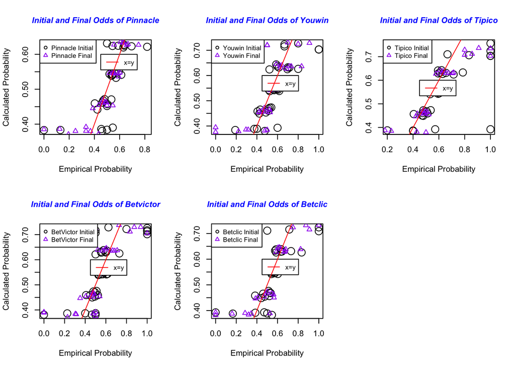

```r
summary_table_BetVictor_final=summary_table_BetVictor_final[order(Year)]

plot(summary_table_BetVictor_initial[,list(empirical_over,probabilistic_over)],ylab='Calculated Probability', xlab='Empirical Probability',pch=1,cex=2)

points(summary_table_BetVictor_final[,list(empirical_over,probabilistic_over)],pch=2,cex=1,col='purple')
legend("topleft", c("BetVictor Initial", "BetVictor Final"),
       col=c("black","purple"), pch=1:2, cex=0.8)
legend(0.45,0.6, c("x=y"),
       col=c("red"), lty=1, cex=0.8)
title("Initial and Final Odds of Betvictor",
      cex.main = 1,   font.main= 4, col.main= "blue")
abline(0,1,col='red')

#Betclic initial

Betclic_over_under_initial=odds_ov_un_initial[bookmaker=='Betclic']

Betclic_wide_initial=dcast(Betclic_over_under_initial,
                             matchId~oddtype,
                             value.var='start_odd')

merged_matches_Betclic_initial=merge(matches, Betclic_wide_initial, by='matchId')

merged_matches_Betclic_initial[,probOver:=1/over]
merged_matches_Betclic_initial[,probUnder:=1/under]

merged_matches_Betclic_initial[,totalProb:=probOver+probUnder]

merged_matches_Betclic_initial[,probOver:=probOver/totalProb]
merged_matches_Betclic_initial[,probUnder:=probUnder/totalProb]

merged_matches_Betclic_initial=merged_matches_Betclic_initial[complete.cases(merged_matches_Betclic_initial)]
merged_matches_Betclic_initial[,totalProb:=NULL]

cutpoints=seq(0,1,0.1)
merged_matches_Betclic_initial[,odd_cut_over:=cut(probOver,cutpoints)]

summary_table_Betclic_initial=merged_matches_Betclic_initial[,list(empirical_over=mean(IsOver),
                                                                       probabilistic_over=mean(probOver),.N),
                                                                 by=list(Year,odd_cut_over)]

summary_table_Betclic_initial=summary_table_Betclic_initial[order(Year)]


#Betclic final

Betclic_over_under_final=odds_ov_un_final[bookmaker=='Betclic']

Betclic_wide_final=dcast(Betclic_over_under_final,
                           matchId~oddtype,
                           value.var='final_odd')

merged_matches_Betclic_final=merge(matches, Betclic_wide_final, by='matchId')

merged_matches_Betclic_final[,probOver:=1/over]
merged_matches_Betclic_final[,probUnder:=1/under]

merged_matches_Betclic_final[,totalProb:=probOver+probUnder]

merged_matches_Betclic_final[,probOver:=probOver/totalProb]
merged_matches_Betclic_final[,probUnder:=probUnder/totalProb]

merged_matches_Betclic_final=merged_matches_Betclic_final[complete.cases(merged_matches_Betclic_final)]
merged_matches_Betclic_final[,totalProb:=NULL]

cutpoints=seq(0,1,0.1)
merged_matches_Betclic_final[,odd_cut_over:=cut(probOver,cutpoints)]

summary_table_Betclic_final=merged_matches_Betclic_final[,list(empirical_over=mean(IsOver),
                                                                   probabilistic_over=mean(probOver),.N),
                                                             by=list(Year,odd_cut_over)]

summary_table_Betclic_final=summary_table_Betclic_final[order(Year)]

plot(summary_table_Betclic_initial[,list(empirical_over,probabilistic_over)],ylab='Calculated Probability', xlab='Empirical Probability',pch=1,cex=2)

points(summary_table_Betclic_final[,list(empirical_over,probabilistic_over)],pch=2,cex=1,col='purple')
legend("topleft", c("Betclic Initial", "Betclic Final"),
       col=c("black","purple"), pch=1:2, cex=0.8)
legend(0.45,0.6, c("x=y"),
       col=c("red"), lty=1, cex=0.8)
title("Initial and Final Odds of Betclic",
      cex.main = 1,   font.main= 4, col.main= "blue")
abline(0,1,col='red')
```

1.a In order to observe if bookmarkers are good at deciding match odds, probabilistic and emprical values of over odds given by the 5 different bookmakers are plotted as seen above. Sometimes, bookmakers provide many different odds before the matches. These graphs only include the initial and the final odds. Intuitively, we expect the mean of odds to be around x=y. This indicates if a bookmaker is succesful or not. When we look at the five graphs above, we see a general accumalation around x=y line. Altough some outliers present, most of the data is around the line.

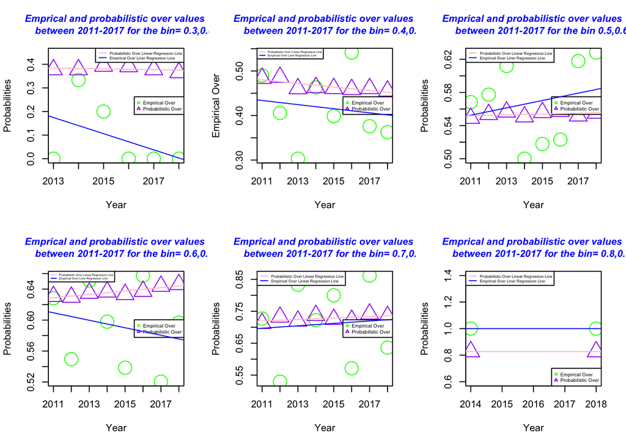

```r
require(data.table)
require(anytime)



matches=readRDS ('/Users/esinakgul/Documents/BOUN/4-1/IE 582/HOMEWORK/Homework 1/df9b1196-e3cf-4cc7-9159-f236fe738215_matches.rds')

odds=readRDS ('/Users/esinakgul/Documents/BOUN/4-1/IE 582/HOMEWORK/Homework 1/df9b1196-e3cf-4cc7-9159-f236fe738215_odd_details.rds')


matches[,match_time:=anytime(date)]
matches[,c("HomeGoals","AwayGoals"):=tstrsplit(score,':')]
matches[,Year:=year(match_time)]

matches$HomeGoals=as.numeric(matches$HomeGoals)
matches[,AwayGoals:=as.numeric(AwayGoals)]


matches[,TotalGoals:=HomeGoals+AwayGoals]

matches[,IsOver:=0]
matches[TotalGoals>2,IsOver:=1]

matches=matches[complete.cases(matches)]

odds_ov_un=odds[betType=='ou' & totalhandicap=='2.5']

odds_ov_un[,totalhandicap:=NULL]

odds_ov_un=odds_ov_un[order(matchId, oddtype,bookmaker,date)]

odds_ov_un_initial=odds_ov_un[,list(start_odd=odd[1]),
                              by=list(matchId,oddtype,bookmaker)]

odds_ov_un_final=odds_ov_un[,list(final_odd=odd[.N]),
                            by=list(matchId,oddtype,bookmaker)]

#First Question b section

betclic_over=odds_ov_un_final[oddtype=='over' & bookmaker=='Betclic']

betclic_wide_over=dcast(betclic_over,
                        matchId~oddtype,
                        value.var='final_odd')

merged_Betclic_over=merge(matches, betclic_wide_over, by='matchId')

merged_Betclic_over[,probOver:=1/over]
merged_Betclic_over=merged_Betclic_over[order(Year)]
cutpoints=seq(0,1,0.1)

merged_Betclic_over[,odd_cut_over:=cut(probOver,cutpoints)]
summary_table_Betclic_over=merged_Betclic_over[,list(empirical_over=mean(IsOver),
                                                     probabilistic_over=mean(probOver),.N),
                                               by=list(Year,odd_cut_over)]

par(mfrow=c(2,3))

firstbin=summary_table_Betclic_over[odd_cut_over =='(0.3,0.4]']
x1=firstbin[,Year]
y1=firstbin[,empirical_over]
y2=firstbin[,probabilistic_over]
plot(x1,y1, xlab='Year', ylab='Probabilities', ylim=c(0,0.45), pch=1,cex=3, col='green')
points(x1,y2,  pch=2,cex=3, col='purple')
legend("right", c("Empirical Over", "Probabilistic Over"),
       col=c("green","purple"), pch=1:2, cex=0.5)
legend("topright", c("Probabilistic Over Linear Regression Line","Empirical Over Liner Regression Line "),
       col=c("pink","blue"), lty=1, cex=0.4)
title("Emprical and probabilistic over values
      between 2011-2017 for the bin= 0.3,0.4",
      cex.main = 1,   font.main= 4, col.main= "blue")
abline(lm(y1~x1),col='blue' )
abline(lm(y2~x1),col='pink' )


secondbin=summary_table_Betclic_over[odd_cut_over =='(0.4,0.5]']
x1=secondbin[,Year]
y1=secondbin[,empirical_over]
y2=secondbin[,probabilistic_over]
plot(x1,y1, xlab='Year', ylab='Empirical Over', pch=1,cex=3, col='green')
points(x1,y2,  pch=2,cex=3, col='purple')
legend("right", c("Empirical Over", "Probabilistic Over"),
       col=c("green","purple"), pch=1:2, cex=0.5)
legend("topleft", c("Probabilistic Over Linear Regression Line","Empirical Over Liner Regression Line "),
       col=c("pink","blue"), lty=1, cex=0.3)
title("Emprical and probabilistic over values
      between 2011-2017 for the bin= 0.4,0.5",
      cex.main = 1,   font.main= 4, col.main= "blue")
abline(lm(y2~x1),col='pink' )
abline(lm(y1~x1),col='blue' )




thirdbin=summary_table_Betclic_over[odd_cut_over =='(0.5,0.6]']
x1=thirdbin[,Year]
y1=thirdbin[,empirical_over]
y2=thirdbin[,probabilistic_over]
plot(x1,y1, xlab='Year', ylab='Probabilities', pch=1,cex=3, col='green')
points(x1,y2,  pch=2,cex=3, col='purple')
legend("right", c("Empirical Over", "Probabilistic Over"),
       col=c("green","purple"), pch=1:2, cex=0.5)
legend("topleft", c("Probabilistic Over Linear Regression Line","Empirical Over Liner Regression Line "),
       col=c("pink","blue"), lty=1, cex=0.4)
title("Emprical and probabilistic over values
      between 2011-2017 for the bin 0.5,0.6",
      cex.main = 1,   font.main= 4, col.main= "blue")
abline(lm(y1~x1),col='blue' )
abline(lm(y2~x1),col='pink' )


fourthbin=summary_table_Betclic_over[odd_cut_over =='(0.6,0.7]']
x1=fourthbin[,Year]
y1=fourthbin[,empirical_over]
y2=fourthbin[,probabilistic_over]
plot(x1,y1, xlab='Year', ylab='Probabilities', pch=1,cex=3, col='green')
points(x1,y2,  pch=2,cex=3, col='purple')
legend("right", c("Empirical Over", "Probabilistic Over"),
       col=c("green","purple"), pch=1:2, cex=0.5)
legend("topleft", c("Probabilistic Over Linear Regression Line","Empirical Over Liner Regression Line "),
       col=c("pink","blue"), lty=1, cex=0.3)
title("Emprical and probabilistic over values
      between 2011-2017 for the bin= 0.6,0.7",
      cex.main = 1,   font.main= 4, col.main= "blue")
abline(lm(y1~x1),col='blue' )
abline(lm(y2~x1),col='pink' )


fifthbin=summary_table_Betclic_over[odd_cut_over =='(0.7,0.8]']
x1=fifthbin[,Year]
y1=fifthbin[,empirical_over]
y2=fifthbin[,probabilistic_over]
plot(x1,y1, xlab='Year', ylab='Probabilities', pch=1,cex=3, col='green')
points(x1,y2,  pch=2,cex=3, col='purple')
legend("right", c("Empirical Over", "Probabilistic Over"),
       col=c("green","purple"), pch=1:2, cex=0.5)
legend("topleft", c("Probabilistic Over Linear Regression Line","Empirical Over Linear Regression Line "),
       col=c("pink","blue"), lty=1, cex=0.4)
title("Emprical and probabilistic over values
      between 2011-2017 for the bin= 0.7,0.8",
      cex.main = 1,   font.main= 4, col.main= "blue")
abline(lm(y1~x1),col='blue' )
abline(lm(y2~x1),col='pink' )

sixthbin=summary_table_Betclic_over[odd_cut_over =='(0.8,0.9]']
x1=sixthbin[,Year]
y1=sixthbin[,empirical_over]
y2=sixthbin[,probabilistic_over]
plot(x1,y1, xlab='Year', ylab='Probabilities', pch=1,cex=3, col='green')
points(x1,y2,  pch=2,cex=3, col='purple')
legend("bottomright", c("Empirical Over", "Probabilistic Over"),
       col=c("green","purple"), pch=1:2, cex=0.5)
legend("topleft", c("Probabilistic Over Linear Regression Line","Empirical Over Liner Regression Line "),
       col=c("pink","blue"), lty=1, cex=0.4)
title("Emprical and probabilistic over values
      between 2011-2017 for the bin= 0.8,0.9",
      cex.main = 1,   font.main= 4, col.main= "blue")
abline(lm(y1~x1),col='blue' )
abline(lm(y2~x1),col='pink' )
```

1.b First of all, to perform the analysis over time for several bins Betclic, which is the name of a bookmaker, is chosen. Also this is an analysis for over under odd type with totalhandicap being equal to 2.5. The bins are created with 0.1 increments. When the data was summarized, there was no probability that falls in (0,0.1), (0.1,0.2) and (0.2,0.3) (0.9,1) bins. Therefore, their graphes are not plotted above. When we observe the graphs above, we can clearly comment on the behaviour of empirical and probabilistic results of the bins. Both empirical and probabilistic data is plotted in the graphs for comparison. We can say that in the interval of (0.7, 0.8), empirical and probabilistic over linear regression lines come to the closest position of all bins. It is also apparent that probabilistic values do not fluctuate over time as much as empirical results. There isn’t a clear evidence that bookmaker Betclic improved itself to give odds near the probabilistic result over time.

```r
require(data.table)
require(anytime)
require(plyr)
```

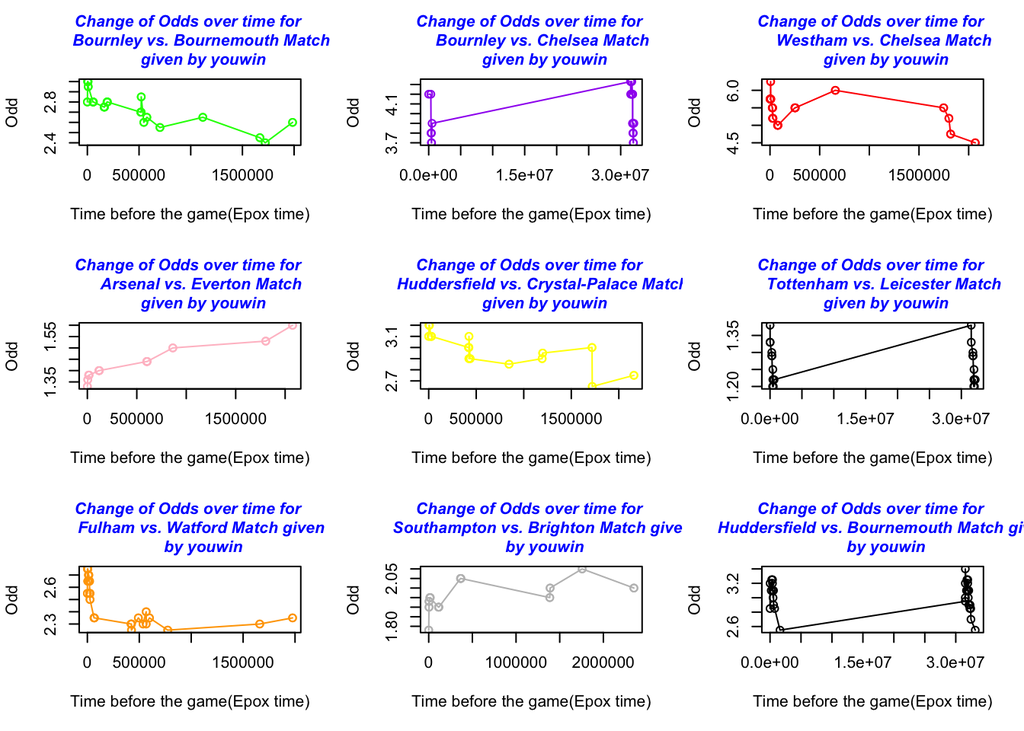

```r
matches=readRDS ('/Users/esinakgul/Documents/BOUN/4-1/IE 582/HOMEWORK/Homework 1/df9b1196-e3cf-4cc7-9159-f236fe738215_matches.rds')

odds=readRDS ('/Users/esinakgul/Documents/BOUN/4-1/IE 582/HOMEWORK/Homework 1/df9b1196-e3cf-4cc7-9159-f236fe738215_odd_details.rds')


matches[,match_time:=anytime(date)]
matches[,c("HomeGoals","AwayGoals"):=tstrsplit(score,':')]
matches[,Year:=year(match_time)]

matches=matches[complete.cases(matches)]

odds_onetwo=odds[betType=='1x2' & bookmaker=='youwin' & oddtype=='odd1']

odds_onetwo[,totalhandicap:=NULL]
odds_onetwo=odds_onetwo[order(matchId, date)]

odds_onetwo[,odds_time:=anytime(date)]

merged_onetwo=merge(matches, odds_onetwo, by='matchId')
merged_onetwo=merged_onetwo[,leagueId:=NULL]
merged_onetwo=merged_onetwo[,home:=NULL]
merged_onetwo=merged_onetwo[,away:=NULL]
merged_onetwo=merged_onetwo[,HomeGoals:=NULL]
merged_onetwo=merged_onetwo[,AwayGoals:=NULL]
merged_onetwo=merged_onetwo[,Year:=NULL]
merged_onetwo[,subtraction:= date.x-date.y]

frequency_table=count(merged_onetwo,'matchId')
new_merged=merge(merged_onetwo, frequency_table, by='matchId')

par(mfrow=c(3,3))
new_merged=new_merged[order(subtraction)]
first_match=new_merged[matchId=='j3rMpxl5']
plot(first_match[,subtraction], first_match[,odd],xlab="Time before the game(Epox time)", ylab = "Odd", col='green', type='o')
title("Change of Odds over time for
      Bournley vs. Bournemouth Match
      given by youwin",
      cex.main = 1,   font.main= 4, col.main= "blue")

second_match=new_merged[matchId=='46OanUK6']
plot(second_match[,subtraction], second_match[,odd],xlab="Time before the game(Epox time)", ylab = "Odd", col='purple', type='o')
title("Change of Odds over time for
      Bournley vs. Chelsea Match
      given by youwin",
      cex.main = 1,   font.main= 4, col.main= "blue")

third_match=new_merged[matchId=='pK6po6ao']
plot(third_match[,subtraction], third_match[,odd],xlab="Time before the game(Epox time)", ylab = "Odd", col='red', type='o')
title("Change of Odds over time for
      Westham vs. Chelsea Match
      given by youwin",
      cex.main = 1,   font.main= 4, col.main= "blue")

fourth_match=new_merged[matchId=='IkpEnbJh']
plot(fourth_match[,subtraction], fourth_match[,odd],xlab="Time before the game(Epox time)", ylab = "Odd", col='pink', type='o')
title("Change of Odds over time for
      Arsenal vs. Everton Match
      given by youwin",
      cex.main = 1,   font.main= 4, col.main= "blue")

fifth_match=new_merged[matchId=='2JNrXIJ5']
plot(fifth_match[,subtraction], fifth_match[,odd],xlab="Time before the game(Epox time)", ylab = "Odd", col='yellow', type='o')
title("Change of Odds over time for
      Huddersfield vs. Crystal-Palace Match
      given by youwin",
      cex.main = 1,   font.main= 4, col.main= "blue")

sixth_match=new_merged[matchId=='vei0UAHB']
plot(sixth_match[,subtraction],sixth_match[,odd], xlab="Time before the game(Epox time)", ylab = "Odd",col='black', type='o')
title("Change of Odds over time for
      Tottenham vs. Leicester Match
      given by youwin",
      cex.main = 1,   font.main= 4, col.main= "blue")

seventh_match=new_merged[matchId=='WCjUrGIH']
plot(seventh_match[,subtraction],seventh_match[,odd],xlab="Time before the game(Epox time)", ylab = "Odd", col='orange', type='o')
title("Change of Odds over time for
      Fulham vs. Watford Match given
      by youwin",
      cex.main = 1,   font.main= 4, col.main= "blue")


eight_match=new_merged[matchId=='WbBeUG3O']
plot(eight_match[,subtraction],eight_match[,odd], xlab="Time before the game(Epox time)", ylab = "Odd",col='grey', type='o')
title("Change of Odds over time for
      Southampton vs. Brighton Match given
      by youwin",
      cex.main = 1,   font.main= 4, col.main= "blue")



ninth_match=new_merged[matchId=='Qc2IIb09']
plot(ninth_match[,subtraction],ninth_match[,odd],xlab="Time before the game(Epox time)", ylab = "Odd", col='black', type='o')
title("Change of Odds over time for
      Huddersfield vs. Bournemouth Match given
      by youwin",
      cex.main = 1,   font.main= 4, col.main= "blue")
```

2. Many of the bookmakers provide several odds before a match. Someof them start to give odds months ago. Therefore, fluctuation is expected over time due to many reason. An injury of the favorite player in a game or a coach change would affect the odds provided. The graphs above are drawn to observe fluctions of the odds before the game. To be able to see clearly, analysis is performed on 9 matches, with the highest frequency of odd change. The epox time scale is not converted to date since seeing the general trend will be important regardless of the date. On x axis, 0 indicates the match time. As we move on to the right it is time before the match time. For the sake of simplicity, this anaylsis is performed only on betType 1x2 with odd type of BET1. I believe this will be enough to see the fluctions before the match time. Therefore, other types of odds are not plotted in 1x2 Bettype. We see that the changes in odds with the highest frequency occured before the match of well-known teams. Additionally, odds of Tottenham vs. Leicester game are provided long time ago with respect to Fulham cs. Watford game. This is also the case for Bournley and Chelsea game. We cannot say that there is a general trend that odds will be raised just before the game. This increase and decrease can not be accurately commented without studying the significant events happened at that time. However, as i mentioned before, an injury or a considerable change in the teams can be cause of this increase or decrease.